#Using the ‘mlr’ package

```r
# create a svm classification task
svm_task <- makeClassifTask(id = "svm", data = training_set,
                            target = "TenYearCHD")
svm_task
```

```
## Supervised task: svm
## Type: classif
## Target: TenYearCHD
## Observations: 3702
## Features:
##    numerics     factors     ordered functionals
##          14           0           0           0
## Missings: FALSE
## Has weights: FALSE
## Has blocking: FALSE
## Has coordinates: FALSE
## Classes: 2
##    0    1
## 1783 1919
## Positive class: 0
```

```r
# create a svm learner
svm_lrn <- makeLearner("classif.svm", kernel="radial")
svm_lrn
```

```
## Learner classif.svm from package e1071
## Type: classif
## Name: Support Vector Machines (libsvm); Short name: svm
## Class: classif.svm
## Properties: twoclass,multiclass,numerics,factors,prob,class.weights
## Predict-Type: response
## Hyperparameters: kernel=radial
```

```r
# train the svm classifier using mlr and get the model
svm_mod <- train(svm_lrn, svm_task)
svm_mod$learner.model
```

```
##
## Call:
## svm.default(x = d$data, y = d$target, kernel = "radial", probability = .learner$predict.type ==
##     "prob")
##
##
## Parameters:
##    SVM-Type:  C-classification
##  SVM-Kernel:  radial
##        cost:  1
##
## Number of Support Vectors:  2615
```

```r
#check the features
svm_mod$features
```

```
##  [1] "age"             "sex"             "is_smoking"      "cigsPerDay"
##  [5] "BPMeds"          "prevalentStroke" "prevalentHyp"    "diabetes"
##  [9] "totChol"         "sysBP"           "diaBP"           "BMI"
## [13] "heartRate"       "glucose"
```

```r
#how long to train it
svm_mod$time
```

```
## [1] 1.95
```

```r
#predication
#predication for the training dataset
train_pred <- predict(svm_mod, svm_task); train_pred
```

```
## Prediction: 3702 observations
## predict.type: response
## threshold:
## time: 0.56
##    id truth response
## 2   1     1        1
## 5   2     1        1
## 6   3     1        1
## 8   4     1        0
## 9   5     1        1
## 10  6     1        0
## ... (#rows: 3702, #cols: 3)
```

```r
#predication for the test dataset
test_pred <- predict(svm_mod, newdata=test_set); test_pred
```

```
## Prediction: 1587 observations
## predict.type: response
## threshold:
## time: 0.25
##    truth response
## 1      1        1
## 3      1        1
## 4      1        1
## 7      1        1
## 27     1        1
## 30     1        1
## ... (#rows: 1587, #cols: 2)
```

```r
calculateConfusionMatrix(train_pred)
```

```
##         predicted
## true        0    1 -err.-
##   0      1257  526    526
##   1       474 1445    474
##   -err.-  474  526   1000
```

```r
calculateConfusionMatrix(test_pred)
```

```
##         predicted
## true       0   1 -err.-
##   0      524 240    240
##   1      206 617    206
##   -err.- 206 240    446
```

```r
calculateConfusionMatrix(train_pred, relative = TRUE , sums= TRUE)
```

```
## Relative confusion matrix (normalized by row/column):
##         predicted
## true     0         1         -err.-    -n-
##   0      0.70/0.73 0.30/0.27 0.30      1731
##   1      0.25/0.27 0.75/0.73 0.25      1971
##   -err.-      0.27      0.27 0.27      <NA>
##   -n-    1783      1919      <NA>      3702
##
##
## Absolute confusion matrix:
##           0    1 -err.-  -n-
## 0      1257  526    526 1783
## 1       474 1445    474 1919
## -err.-  474  526   1000   NA
## -n-    1731 1971     NA 3702
```

```r
calculateConfusionMatrix(test_pred, relative = TRUE , sums= TRUE)
```

```
## Relative confusion matrix (normalized by row/column):
##         predicted
## true     0         1         -err.-    -n-
##   0      0.69/0.72 0.31/0.28 0.31      730
##   1      0.25/0.28 0.75/0.72 0.25      857
##   -err.-      0.28      0.28 0.28      <NA>
##   -n-    764       823       <NA>      3702
##
##
## Absolute confusion matrix:
##          0   1 -err.-  -n-
## 0      524 240    240  764
## 1      206 617    206  823
## -err.- 206 240    446   NA
## -n-    730 857     NA 3702
```

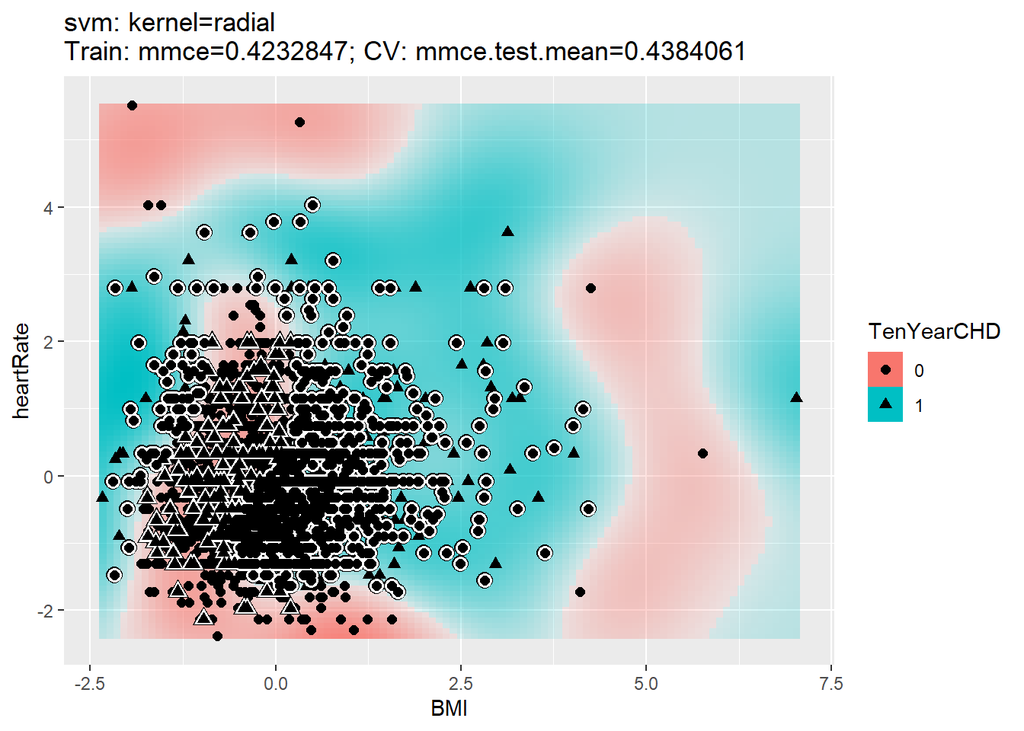

```r
#viusaliaze and comparing the predication
plotLearnerPrediction(svm_lrn, task= svm_task,

                      features = c("BMI","heartRate"))
```

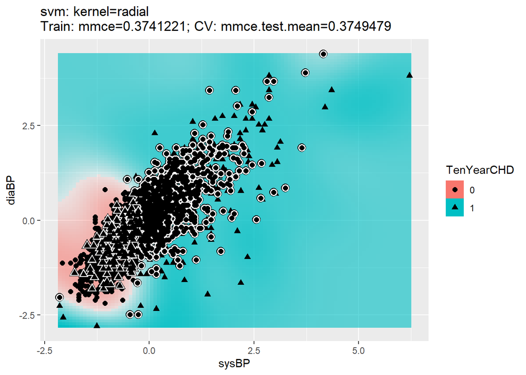

```r
plotLearnerPrediction(svm_lrn, task= svm_task,

                      features = c("sysBP","diaBP"))
```

```r
#classification for all the result
listMeasures(svm_task)
```

```
##  [1] "tnr"              "tpr"              "featperc"         "f1"
##  [5] "mmce"             "mcc"              "brier.scaled"     "lsr"
##  [9] "bac"              "fn"               "fp"               "fnr"
## [13] "qsr"              "fpr"              "npv"              "brier"
## [17] "auc"              "timeboth"         "multiclass.aunp"  "timetrain"
## [21] "multiclass.aunu"  "ber"              "timepredict"      "multiclass.brier"
## [25] "ssr"              "ppv"              "acc"              "logloss"
## [29] "wkappa"           "tn"               "tp"               "multiclass.au1p"
## [33] "multiclass.au1u"  "fdr"              "kappa"            "gpr"
## [37] "gmean"
```

```r
#get the default measure for svm
getDefaultMeasure(svm_task)
```

```
## Name: Mean misclassification error
## Performance measure: mmce
## Properties: classif,classif.multi,req.pred,req.truth
## Minimize: TRUE
## Best: 0; Worst: 1
## Aggregated by: test.mean
## Arguments:
## Note: Defined as: mean(response != truth)
```

```r
#preformance the predication
performance(test_pred)
```

```
##      mmce
## 0.2810334
```

performance(test_pred, measures = acc)

```r
# tune the model base on set the continuous parameter sets
rdesc <- makeResampleDesc(method = "CV", iters=10)
num_ps <- makeParamSet(
  makeNumericParam("cost", lower = -1, upper = 1, trafo =
                     function(x) 10^x),
  makeNumericParam("gamma", lower = -1, upper = 1, trafo =
                     function(x) 10^x)
)
ctrl <- makeTuneControlRandom(maxit = 100L)
res <- tuneParams("classif.svm", task = svm_task,
                  resampling = rdesc,
                  par.set = num_ps,
                  control = ctrl,
                  measures = list(acc, mmce),
                  show.info = TRUE)
```

```
## [Tune] Started tuning learner classif.svm for parameter set:
```

```
##          Type len Def  Constr Req Tunable Trafo
## cost  numeric   -   - -1 to 1   -    TRUE     Y
## gamma numeric   -   - -1 to 1   -    TRUE     Y
```

```
## With control class: TuneControlRandom
```

```
## Imputation value: -0Imputation value: 1
```

```
## [Tune-x] 1: cost=0.399; gamma=0.143
```

```
## [Tune-y] 1: acc.test.mean=0.7004305,mmce.test.mean=0.2995695; time: 0.3 min
```

```
## [Tune-x] 2: cost=0.787; gamma=0.547
```

```
## [Tune-y] 2: acc.test.mean=0.8581780,mmce.test.mean=0.1418220; time: 0.3 min
```

```
## [Tune-x] 3: cost=0.401; gamma=0.847
```

```
## [Tune-y] 3: acc.test.mean=0.8708778,mmce.test.mean=0.1291222; time: 0.4 min
```

```
## [Tune-x] 4: cost=8.9; gamma=6.82
```

```
## [Tune-y] 4: acc.test.mean=0.9943243,mmce.test.mean=0.0056757; time: 0.3 min
```

```
## [Tune-x] 5: cost=1; gamma=5.58
```

```
## [Tune-y] 5: acc.test.mean=0.9943243,mmce.test.mean=0.0056757; time: 0.4 min
```

```
## [Tune-x] 6: cost=0.136; gamma=0.207
```

```
## [Tune-y] 6: acc.test.mean=0.6869178,mmce.test.mean=0.3130822; time: 0.4 min
```

```
## [Tune-x] 7: cost=0.149; gamma=0.493
```

```
## [Tune-y] 7: acc.test.mean=0.6944780,mmce.test.mean=0.3055220; time: 0.4 min
```

```
## [Tune-x] 8: cost=0.215; gamma=0.974
```

```
## [Tune-y] 8: acc.test.mean=0.7258097,mmce.test.mean=0.2741903; time: 0.4 min
```

```
## [Tune-x] 9: cost=0.613; gamma=3.48
```

```
## [Tune-y] 9: acc.test.mean=0.9886516,mmce.test.mean=0.0113484; time: 0.4 min
```

```
## [Tune-x] 10: cost=0.481; gamma=7.88
```

```
## [Tune-y] 10: acc.test.mean=0.9662271,mmce.test.mean=0.0337729; time: 0.4 min
```

```
## [Tune-x] 11: cost=4.98; gamma=2.21
```

```
## [Tune-y] 11: acc.test.mean=0.9867611,mmce.test.mean=0.0132389; time: 0.3 min
```

```
## [Tune-x] 12: cost=0.228; gamma=3.96
```

```
## [Tune-y] 12: acc.test.mean=0.6625475,mmce.test.mean=0.3374525; time: 0.4 min
```

```
## [Tune-x] 13: cost=0.878; gamma=1.1
```

```
## [Tune-y] 13: acc.test.mean=0.9443484,mmce.test.mean=0.0556516; time: 0.4 min
```

```
## [Tune-x] 14: cost=9.18; gamma=0.102
```

```
## [Tune-y] 14: acc.test.mean=0.7798412,mmce.test.mean=0.2201588; time: 0.4 min
```

```
## [Tune-x] 15: cost=6.99; gamma=0.226
```

```
## [Tune-y] 15: acc.test.mean=0.8522365,mmce.test.mean=0.1477635; time: 0.3 min
```

```
## [Tune-x] 16: cost=0.519; gamma=2.74
```

```
## [Tune-y] 16: acc.test.mean=0.9697385,mmce.test.mean=0.0302615; time: 0.5 min
```

```
## [Tune-x] 17: cost=0.209; gamma=2.73
```

```
## [Tune-y] 17: acc.test.mean=0.6010060,mmce.test.mean=0.3989940; time: 0.5 min
```

```
## [Tune-x] 18: cost=0.32; gamma=0.127
```

```
## [Tune-y] 18: acc.test.mean=0.6931383,mmce.test.mean=0.3068617; time: 0.4 min
```

```
## [Tune-x] 19: cost=0.283; gamma=0.482
```

```
## [Tune-y] 19: acc.test.mean=0.7433664,mmce.test.mean=0.2566336; time: 0.4 min
```

```
## [Tune-x] 20: cost=0.816; gamma=0.253
```

```
## [Tune-y] 20: acc.test.mean=0.7725468,mmce.test.mean=0.2274532; time: 0.3 min
```

```
## [Tune-x] 21: cost=2.17; gamma=0.411
```

```
## [Tune-y] 21: acc.test.mean=0.8749282,mmce.test.mean=0.1250718; time: 0.3 min
```

```
## [Tune-x] 22: cost=3.08; gamma=8.06
```

```
## [Tune-y] 22: acc.test.mean=0.9943243,mmce.test.mean=0.0056757; time: 0.3 min
```

```
## [Tune-x] 23: cost=2.48; gamma=0.471
```

```
## [Tune-y] 23: acc.test.mean=0.8919443,mmce.test.mean=0.1080557; time: 0.3 min
```

```
## [Tune-x] 24: cost=5.73; gamma=0.179
```

```
## [Tune-y] 24: acc.test.mean=0.8187397,mmce.test.mean=0.1812603; time: 0.3 min
```

```
## [Tune-x] 25: cost=0.126; gamma=1.77
```

```
## [Tune-y] 25: acc.test.mean=0.5337546,mmce.test.mean=0.4662454; time: 0.5 min
```

```
## [Tune-x] 26: cost=2.22; gamma=6.49
```

```
## [Tune-y] 26: acc.test.mean=0.9943243,mmce.test.mean=0.0056757; time: 0.3 min
```

```
## [Tune-x] 27: cost=0.126; gamma=1.04
```

```
## [Tune-y] 27: acc.test.mean=0.6112741,mmce.test.mean=0.3887259; time: 0.4 min
```

```
## [Tune-x] 28: cost=0.618; gamma=4.7
```

```
## [Tune-y] 28: acc.test.mean=0.9913521,mmce.test.mean=0.0086479; time: 0.4 min
```

```
## [Tune-x] 29: cost=0.353; gamma=0.347
```

```
## [Tune-y] 29: acc.test.mean=0.7390522,mmce.test.mean=0.2609478; time: 0.4 min
```

```
## [Tune-x] 30: cost=5.39; gamma=1.17
```

```
## [Tune-y] 30: acc.test.mean=0.9651490,mmce.test.mean=0.0348510; time: 0.3 min
```

```
## [Tune-x] 31: cost=2.08; gamma=0.219
```

```
## [Tune-y] 31: acc.test.mean=0.8073927,mmce.test.mean=0.1926073; time: 0.3 min
```

```
## [Tune-x] 32: cost=1.59; gamma=2.31
```

```
## [Tune-y] 32: acc.test.mean=0.9873017,mmce.test.mean=0.0126983; time: 0.3 min
```

```
## [Tune-x] 33: cost=3.03; gamma=3.64
```

```
## [Tune-y] 33: acc.test.mean=0.9932447,mmce.test.mean=0.0067553; time: 0.3 min
```

```
## [Tune-x] 34: cost=0.479; gamma=3.03
```

```
## [Tune-y] 34: acc.test.mean=0.9643374,mmce.test.mean=0.0356626; time: 0.4 min
```

```
## [Tune-x] 35: cost=0.212; gamma=0.236
```

```
## [Tune-y] 35: acc.test.mean=0.7017746,mmce.test.mean=0.2982254; time: 0.4 min
```

```
## [Tune-x] 36: cost=0.341; gamma=0.113
```

```
## [Tune-y] 36: acc.test.mean=0.6920580,mmce.test.mean=0.3079420; time: 0.3 min
```

```
## [Tune-x] 37: cost=0.345; gamma=0.739
```

```
## [Tune-y] 37: acc.test.mean=0.8141502,mmce.test.mean=0.1858498; time: 0.5 min
```

```
## [Tune-x] 38: cost=0.754; gamma=0.163
```

```
## [Tune-y] 38: acc.test.mean=0.7325752,mmce.test.mean=0.2674248; time: 0.3 min
```

```
## [Tune-x] 39: cost=0.597; gamma=0.848
```

```
## [Tune-y] 39: acc.test.mean=0.9027508,mmce.test.mean=0.0972492; time: 0.4 min
```

```
## [Tune-x] 40: cost=2.18; gamma=3.1
```

```
## [Tune-y] 40: acc.test.mean=0.9921643,mmce.test.mean=0.0078357; time: 0.3 min
```

```
## [Tune-x] 41: cost=0.571; gamma=0.183
```

```
## [Tune-y] 41: acc.test.mean=0.7266307,mmce.test.mean=0.2733693; time: 0.3 min
```

```
## [Tune-x] 42: cost=0.14; gamma=0.668
```

```
## [Tune-y] 42: acc.test.mean=0.6747578,mmce.test.mean=0.3252422; time: 0.4 min
```

```
## [Tune-x] 43: cost=1.94; gamma=0.103
```

```
## [Tune-y] 43: acc.test.mean=0.7352786,mmce.test.mean=0.2647214; time: 0.3 min
```

```
## [Tune-x] 44: cost=0.627; gamma=0.13
```

```
## [Tune-y] 44: acc.test.mean=0.7104247,mmce.test.mean=0.2895753; time: 0.3 min
```

```
## [Tune-x] 45: cost=0.443; gamma=2.23
```

```
## [Tune-y] 45: acc.test.mean=0.9610949,mmce.test.mean=0.0389051; time: 0.4 min
```

```
## [Tune-x] 46: cost=0.155; gamma=0.244
```

```
## [Tune-y] 46: acc.test.mean=0.6912370,mmce.test.mean=0.3087630; time: 0.3 min
```

```
## [Tune-x] 47: cost=1.73; gamma=0.226
```

```
## [Tune-y] 47: acc.test.mean=0.7998303,mmce.test.mean=0.2001697; time: 0.3 min
```

```
## [Tune-x] 48: cost=7.81; gamma=0.902
```

```
## [Tune-y] 48: acc.test.mean=0.9508319,mmce.test.mean=0.0491681; time: 0.3 min
```

```
## [Tune-x] 49: cost=0.708; gamma=1.87
```

```
## [Tune-y] 49: acc.test.mean=0.9743338,mmce.test.mean=0.0256662; time: 0.4 min
```

```
## [Tune-x] 50: cost=5.16; gamma=5.99
```

```
## [Tune-y] 50: acc.test.mean=0.9943243,mmce.test.mean=0.0056757; time: 0.3 min
```

```
## [Tune-x] 51: cost=7.68; gamma=5.11
```

```
## [Tune-y] 51: acc.test.mean=0.9943243,mmce.test.mean=0.0056757; time: 0.3 min
```

```
## [Tune-x] 52: cost=3.89; gamma=2.58
```

```
## [Tune-y] 52: acc.test.mean=0.9891928,mmce.test.mean=0.0108072; time: 0.3 min
```

```
## [Tune-x] 53: cost=3.4; gamma=0.378
```

```
## [Tune-y] 53: acc.test.mean=0.8824922,mmce.test.mean=0.1175078; time: 0.3 min
```

```
## [Tune-x] 54: cost=1.33; gamma=1.4
```

```
## [Tune-y] 54: acc.test.mean=0.9673104,mmce.test.mean=0.0326896; time: 0.3 min
```

```
## [Tune-x] 55: cost=0.432; gamma=3.26
```

```
## [Tune-y] 55: acc.test.mean=0.9624463,mmce.test.mean=0.0375537; time: 0.4 min
```

```
## [Tune-x] 56: cost=2.29; gamma=0.913
```

```
## [Tune-y] 56: acc.test.mean=0.9456990,mmce.test.mean=0.0543010; time: 0.3 min
```

```
## [Tune-x] 57: cost=1.01; gamma=1.38
```

```
## [Tune-y] 57: acc.test.mean=0.9635266,mmce.test.mean=0.0364734; time: 0.3 min
```

```
## [Tune-x] 58: cost=0.172; gamma=0.423
```

```
## [Tune-y] 58: acc.test.mean=0.7047439,mmce.test.mean=0.2952561; time: 0.4 min
```

```
## [Tune-x] 59: cost=1.09; gamma=3.76
```

```
## [Tune-y] 59: acc.test.mean=0.9932447,mmce.test.mean=0.0067553; time: 0.3 min
```

```
## [Tune-x] 60: cost=0.147; gamma=5.32
```

```
## [Tune-y] 60: acc.test.mean=0.5183602,mmce.test.mean=0.4816398; time: 0.4 min
```

```
## [Tune-x] 61: cost=0.428; gamma=1.42
```

```
## [Tune-y] 61: acc.test.mean=0.9411088,mmce.test.mean=0.0588912; time: 0.4 min
```

```
## [Tune-x] 62: cost=0.758; gamma=0.249
```

```
## [Tune-y] 62: acc.test.mean=0.7639011,mmce.test.mean=0.2360989; time: 0.3 min
```

```
## [Tune-x] 63: cost=0.587; gamma=0.411
```

```
## [Tune-y] 63: acc.test.mean=0.8055059,mmce.test.mean=0.1944941; time: 0.3 min
```

```
## [Tune-x] 64: cost=0.258; gamma=0.162
```

```
## [Tune-y] 64: acc.test.mean=0.6934064,mmce.test.mean=0.3065936; time: 0.3 min
```

```
## [Tune-x] 65: cost=0.565; gamma=1.56
```

```
## [Tune-y] 65: acc.test.mean=0.9600160,mmce.test.mean=0.0399840; time: 0.4 min
```

```
## [Tune-x] 66: cost=0.276; gamma=0.255
```

```
## [Tune-y] 66: acc.test.mean=0.7125789,mmce.test.mean=0.2874211; time: 0.3 min
```

```
## [Tune-x] 67: cost=4.16; gamma=0.122
```

```
## [Tune-y] 67: acc.test.mean=0.7733576,mmce.test.mean=0.2266424; time: 0.3 min
```

```
## [Tune-x] 68: cost=0.489; gamma=1.44
```

```
## [Tune-y] 68: acc.test.mean=0.9486690,mmce.test.mean=0.0513310; time: 0.4 min
```

```
## [Tune-x] 69: cost=0.613; gamma=1.75
```

```
## [Tune-y] 69: acc.test.mean=0.9681219,mmce.test.mean=0.0318781; time: 0.4 min
```

```
## [Tune-x] 70: cost=8.46; gamma=1.49
```

```
## [Tune-y] 70: acc.test.mean=0.9754171,mmce.test.mean=0.0245829; time: 0.3 min
```

```
## [Tune-x] 71: cost=0.377; gamma=0.38
```

```
## [Tune-y] 71: acc.test.mean=0.7474241,mmce.test.mean=0.2525759; time: 0.3 min
```

```
## [Tune-x] 72: cost=0.225; gamma=0.282
```

```
## [Tune-y] 72: acc.test.mean=0.7117688,mmce.test.mean=0.2882312; time: 0.3 min
```

```
## [Tune-x] 73: cost=0.143; gamma=0.338
```

```
## [Tune-y] 73: acc.test.mean=0.6947483,mmce.test.mean=0.3052517; time: 0.3 min
```

```
## [Tune-x] 74: cost=3.66; gamma=1.7
```

```
## [Tune-y] 74: acc.test.mean=0.9797399,mmce.test.mean=0.0202601; time: 0.3 min
```

```
## [Tune-x] 75: cost=1.16; gamma=0.759
```

```
## [Tune-y] 75: acc.test.mean=0.9181438,mmce.test.mean=0.0818562; time: 0.3 min
```

```
## [Tune-x] 76: cost=3.85; gamma=3.19
```

```
## [Tune-y] 76: acc.test.mean=0.9921643,mmce.test.mean=0.0078357; time: 0.3 min
```

```
## [Tune-x] 77: cost=5.26; gamma=1.63
```

```
## [Tune-y] 77: acc.test.mean=0.9781190,mmce.test.mean=0.0218810; time: 0.2 min
```

```
## [Tune-x] 78: cost=0.573; gamma=5.35
```

```
## [Tune-y] 78: acc.test.mean=0.9891906,mmce.test.mean=0.0108094; time: 0.4 min
```

```
## [Tune-x] 79: cost=2.46; gamma=0.219
```

```
## [Tune-y] 79: acc.test.mean=0.8146857,mmce.test.mean=0.1853143; time: 0.3 min
```

```
## [Tune-x] 80: cost=7.42; gamma=0.53
```

```
## [Tune-y] 80: acc.test.mean=0.9208436,mmce.test.mean=0.0791564; time: 0.3 min
```

```
## [Tune-x] 81: cost=0.904; gamma=1.91
```

```
## [Tune-y] 81: acc.test.mean=0.9797370,mmce.test.mean=0.0202630; time: 0.3 min
```

```
## [Tune-x] 82: cost=1.69; gamma=1.57
```

```
## [Tune-y] 82: acc.test.mean=0.9759569,mmce.test.mean=0.0240431; time: 0.3 min
```

```
## [Tune-x] 83: cost=0.541; gamma=4.51
```

```
## [Tune-y] 83: acc.test.mean=0.9681190,mmce.test.mean=0.0318810; time: 0.4 min
```

```
## [Tune-x] 84: cost=0.649; gamma=0.175
```

```
## [Tune-y] 84: acc.test.mean=0.7298725,mmce.test.mean=0.2701275; time: 0.3 min
```

```
## [Tune-x] 85: cost=0.832; gamma=0.587
```

```
## [Tune-y] 85: acc.test.mean=0.8676346,mmce.test.mean=0.1323654; time: 0.4 min
```

```
## [Tune-x] 86: cost=1.72; gamma=5.35
```

```
## [Tune-y] 86: acc.test.mean=0.9943243,mmce.test.mean=0.0056757; time: 0.3 min
```

```
## [Tune-x] 87: cost=1.39; gamma=1.31
```

```
## [Tune-y] 87: acc.test.mean=0.9646077,mmce.test.mean=0.0353923; time: 0.3 min
```

```
## [Tune-x] 88: cost=8.54; gamma=0.227
```

```
## [Tune-y] 88: acc.test.mean=0.8576390,mmce.test.mean=0.1423610; time: 0.3 min
```

```
## [Tune-x] 89: cost=5.87; gamma=0.172
```

```
## [Tune-y] 89: acc.test.mean=0.8157660,mmce.test.mean=0.1842340; time: 0.3 min
```

```
## [Tune-x] 90: cost=1.54; gamma=0.844
```

```
## [Tune-y] 90: acc.test.mean=0.9357070,mmce.test.mean=0.0642930; time: 0.3 min
```

```
## [Tune-x] 91: cost=1.8; gamma=0.46
```

```
## [Tune-y] 91: acc.test.mean=0.8816799,mmce.test.mean=0.1183201; time: 0.3 min
```

```
## [Tune-x] 92: cost=2.27; gamma=8.7
```

```
## [Tune-y] 92: acc.test.mean=0.9943243,mmce.test.mean=0.0056757; time: 0.3 min
```

```
## [Tune-x] 93: cost=5; gamma=0.216
```

```
## [Tune-y] 93: acc.test.mean=0.8341364,mmce.test.mean=0.1658636; time: 0.3 min
```

```
## [Tune-x] 94: cost=2.07; gamma=9.57
```

```
## [Tune-y] 94: acc.test.mean=0.9943243,mmce.test.mean=0.0056757; time: 0.3 min
```

```
## [Tune-x] 95: cost=0.125; gamma=0.241
```

```
## [Tune-y] 95: acc.test.mean=0.6896161,mmce.test.mean=0.3103839; time: 0.4 min
```

```
## [Tune-x] 96: cost=0.848; gamma=0.93
```

```
## [Tune-y] 96: acc.test.mean=0.9278713,mmce.test.mean=0.0721287; time: 0.4 min
```

```
## [Tune-x] 97: cost=0.141; gamma=0.131
```

```
## [Tune-y] 97: acc.test.mean=0.6842202,mmce.test.mean=0.3157798; time: 0.4 min
```

```
## [Tune-x] 98: cost=9.39; gamma=6.33
```

```
## [Tune-y] 98: acc.test.mean=0.9943243,mmce.test.mean=0.0056757; time: 0.3 min
```

```
## [Tune-x] 99: cost=0.829; gamma=0.578
```

```
## [Tune-y] 99: acc.test.mean=0.8657434,mmce.test.mean=0.1342566; time: 0.4 min
```

```
## [Tune-x] 100: cost=0.219; gamma=6.04
```

```
## [Tune-y] 100: acc.test.mean=0.5356407,mmce.test.mean=0.4643593; time: 0.5 min
```

```
## [Tune] Result: cost=1.72; gamma=5.35 : acc.test.mean=0.9943243,mmce.test.mean=0.0056757
```

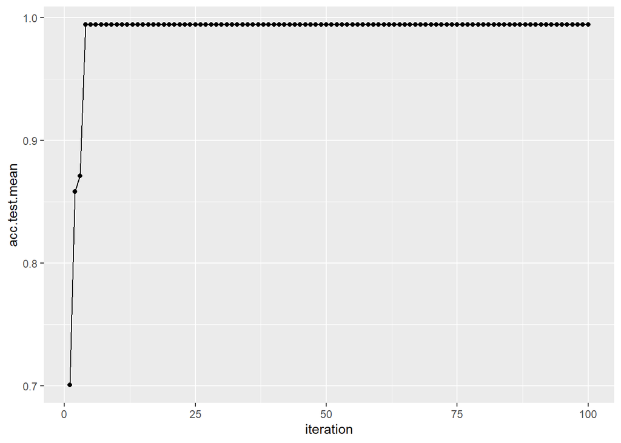

```r
data <- generateHyperParsEffectData(res)
plotHyperParsEffect(data, x = "iteration", y = "acc.test.mean",
                    plot.type = "line")
```

#Analyze and process missing data

```r
setwd("C:/B452f")
df_miss <- read.csv("Cardiovascular_Study_Dataset.csv", header=TRUE)
df_miss = subset(df_miss, select = -c(education,id) )
str(df_miss)
```

```
## 'data.frame':    3390 obs. of  15 variables:
##  $ age            : int  64 36 46 50 64 61 61 36 41 55 ...
##  $ sex            : Factor w/ 2 levels "F","M": 1 2 1 2 1 1 2 2 1 1 ...
##  $ is_smoking     : Factor w/ 2 levels "NO","YES": 2 1 2 2 2 1 1 2 2 1 ...
##  $ cigsPerDay     : int  3 0 10 20 30 0 0 35 20 0 ...
##  $ BPMeds         : int  0 0 0 0 0 0 0 0 NA 0 ...
##  $ prevalentStroke: int  0 0 0 0 0 0 0 0 0 0 ...
##  $ prevalentHyp   : int  0 1 0 1 0 1 1 0 0 1 ...
##  $ diabetes       : int  0 0 0 0 0 0 0 0 0 0 ...
##  $ totChol        : int  221 212 250 233 241 272 238 295 220 326 ...
##  $ sysBP          : num  148 168 116 158 136 ...
##  $ diaBP          : num  85 98 71 88 85 121 136 68 78 81 ...
##  $ BMI            : num  NA 29.8 20.4 28.3 26.4 ...
##  $ heartRate      : int  90 72 88 68 70 85 75 60 86 85 ...
##  $ glucose        : int  80 75 94 94 77 65 79 63 79 NA ...
##  $ TenYearCHD     : int  1 0 0 1 0 1 0 0 0 0 ...
```

```r
head(df_miss)
```

```
##   age sex is_smoking cigsPerDay BPMeds prevalentStroke prevalentHyp diabetes
## 1  64   F        YES          3      0               0            0        0
## 2  36   M         NO          0      0               0            1        0
## 3  46   F        YES         10      0               0            0        0
## 4  50   M        YES         20      0               0            1        0
## 5  64   F        YES         30      0               0            0        0
## 6  61   F         NO          0      0               0            1        0
##   totChol sysBP diaBP   BMI heartRate glucose TenYearCHD
## 1     221 148.0    85    NA        90      80          1
## 2     212 168.0    98 29.77        72      75          0
## 3     250 116.0    71 20.35        88      94          0
## 4     233 158.0    88 28.26        68      94          1
## 5     241 136.5    85 26.42        70      77          0
## 6     272 182.0   121 32.80        85      65          1
```

```r
df_miss$is_smoking <- ifelse(df_miss$is_smoking=="YES", 1, 0)
df_miss$sex <- ifelse(df_miss$sex=="M", 1, 0)
anyNA(df_miss)
```

```
## [1] TRUE
```

```r
df_miss <- df_miss[rowSums(is.na(df_miss)) > 0, ]
summary(df_miss)
```

```
##       age             sex           is_smoking       cigsPerDay
##  Min.   :34.00   Min.   :0.0000   Min.   :0.0000   Min.   : 0.000
##  1st Qu.:42.25   1st Qu.:0.0000   1st Qu.:0.0000   1st Qu.: 0.000
##  Median :49.00   Median :0.0000   Median :1.0000   Median : 1.500
##  Mean   :49.70   Mean   :0.3109   Mean   :0.5363   Mean   : 8.995
##  3rd Qu.:57.00   3rd Qu.:1.0000   3rd Qu.:1.0000   3rd Qu.:20.000
##  Max.   :70.00   Max.   :1.0000   Max.   :1.0000   Max.   :60.000
##                                                    NA's   :22
##      BPMeds        prevalentStroke    prevalentHyp       diabetes
##  Min.   :0.00000   Min.   :0.00000   Min.   :0.0000   Min.   :0.00000
##  1st Qu.:0.00000   1st Qu.:0.00000   1st Qu.:0.0000   1st Qu.:0.00000
##  Median :0.00000   Median :0.00000   Median :0.0000   Median :0.00000
##  Mean   :0.02632   Mean   :0.01036   Mean   :0.3187   Mean   :0.01295
##  3rd Qu.:0.00000   3rd Qu.:0.00000   3rd Qu.:1.0000   3rd Qu.:0.00000
##  Max.   :1.00000   Max.   :1.00000   Max.   :1.0000   Max.   :1.00000
##  NA's   :44
##     totChol          sysBP           diaBP             BMI
##  Min.   :107.0   Min.   : 95.0   Min.   : 50.00   Min.   :16.61
##  1st Qu.:205.0   1st Qu.:117.5   1st Qu.: 74.00   1st Qu.:22.73
##  Median :232.5   Median :127.5   Median : 81.00   Median :25.09
##  Mean   :235.8   Mean   :132.7   Mean   : 82.57   Mean   :25.56
##  3rd Qu.:261.0   3rd Qu.:144.0   3rd Qu.: 89.00   3rd Qu.:27.64
##  Max.   :391.0   Max.   :235.0   Max.   :136.00   Max.   :45.79
##  NA's   :38                                       NA's   :14
##    heartRate         glucose         TenYearCHD
##  Min.   : 48.00   Min.   : 57.00   Min.   :0.0000
##  1st Qu.: 69.00   1st Qu.: 73.00   1st Qu.:0.0000
##  Median : 75.00   Median : 81.50   Median :0.0000
##  Mean   : 77.23   Mean   : 85.51   Mean   :0.1399
##  3rd Qu.: 85.00   3rd Qu.: 89.00   3rd Qu.:0.0000
##  Max.   :112.00   Max.   :297.00   Max.   :1.0000
##  NA's   :1        NA's   :304
```

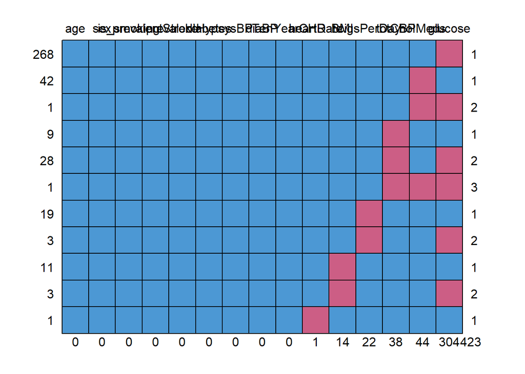

```
##     age sex is_smoking prevalentStroke prevalentHyp diabetes sysBP diaBP
## 268   1   1          1               1            1        1     1     1
## 42    1   1          1               1            1        1     1     1
## 1     1   1          1               1            1        1     1     1
## 9     1   1          1               1            1        1     1     1
## 28    1   1          1               1            1        1     1     1
## 1     1   1          1               1            1        1     1     1
## 19    1   1          1               1            1        1     1     1
## 3     1   1          1               1            1        1     1     1
## 11    1   1          1               1            1        1     1     1
## 3     1   1          1               1            1        1     1     1
## 1     1   1          1               1            1        1     1     1
##       0   0          0               0            0        0     0     0
##     TenYearCHD heartRate BMI cigsPerDay totChol BPMeds glucose
## 268          1         1   1          1       1      1       0   1
## 42           1         1   1          1       1      0       1   1
## 1            1         1   1          1       1      0       0   2
## 9            1         1   1          1       0      1       1   1
## 28           1         1   1          1       0      1       0   2
## 1            1         1   1          1       0      0       0   3
## 19           1         1   1          0       1      1       1   1
## 3            1         1   1          0       1      1       0   2
## 11           1         1   0          1       1      1       1   1
## 3            1         1   0          1       1      1       0   2
## 1            1         0   1          1       1      1       1   1
##              0         1  14         22      38     44     304 423
```

```r
#tabulating missing values
library(mice)
md.pattern(df_miss)
```

```r
# list the rows that have one or more missing values
library(VIM)
df_miss[!complete.cases(df_miss),]
```

[output not shown]

[output cut: 759 more lines]

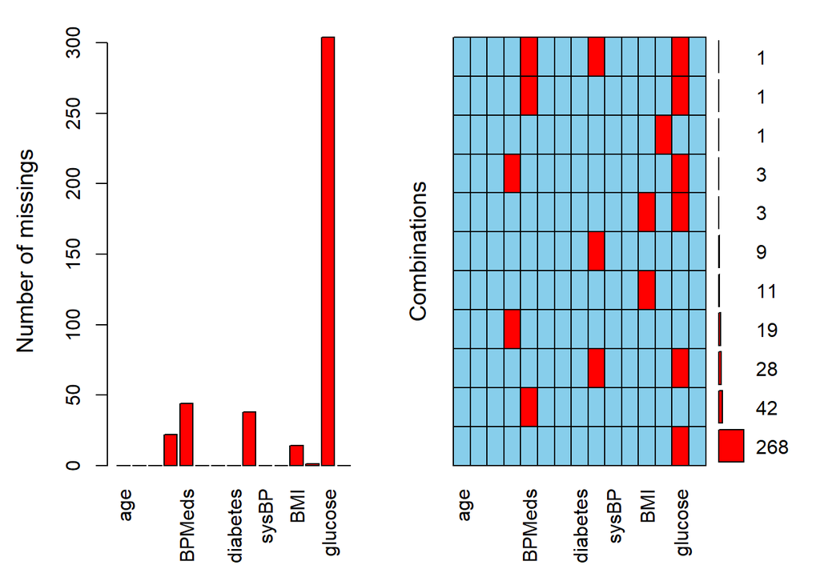

```r
# in number
aggr(df_miss, prop=FALSE, numbers=TRUE)
```

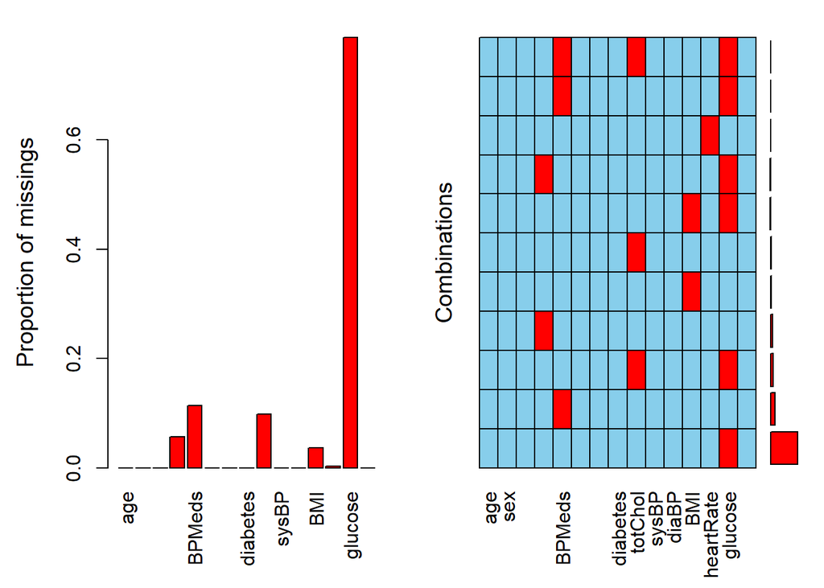

```r
# in proportion
aggr(df_miss, prop=TRUE, numbers=FALSE)
```

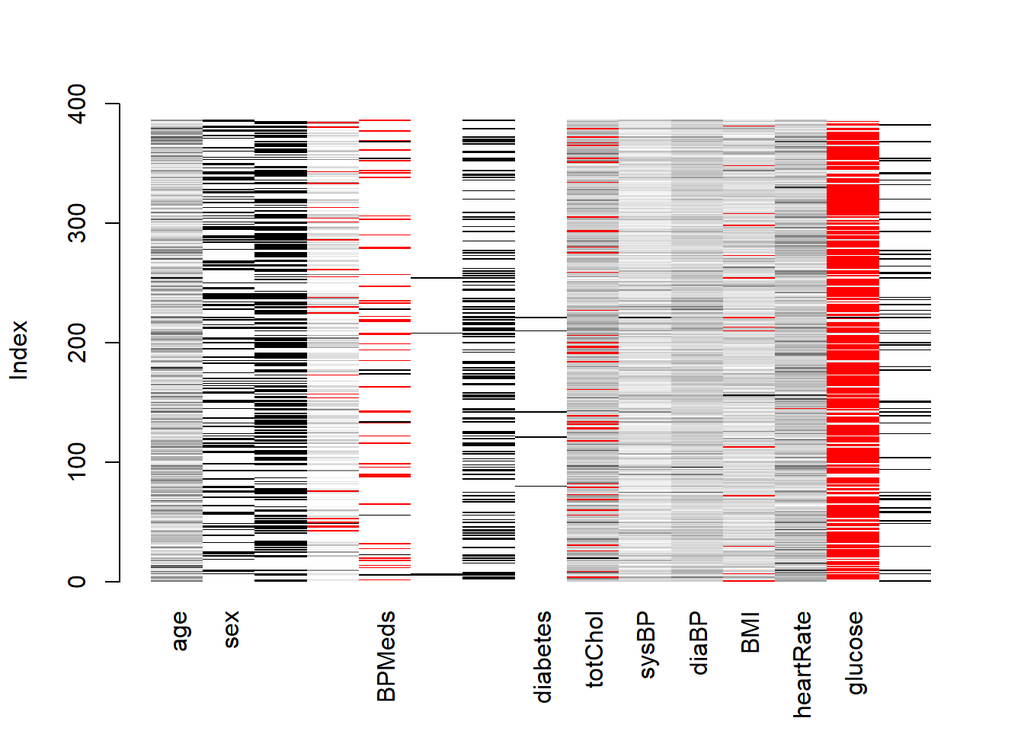

```r
# Matrix plot. Red for missing values, Darker values are high values.
matrixplot(df_miss, interactive=FALSE) # without sorting
```

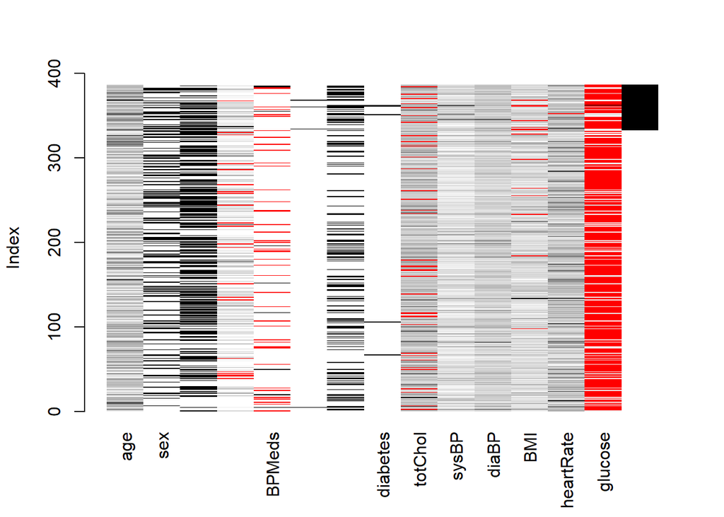

```r
matrixplot(df_miss, interactive=FALSE, sortby="TenYearCHD")
```

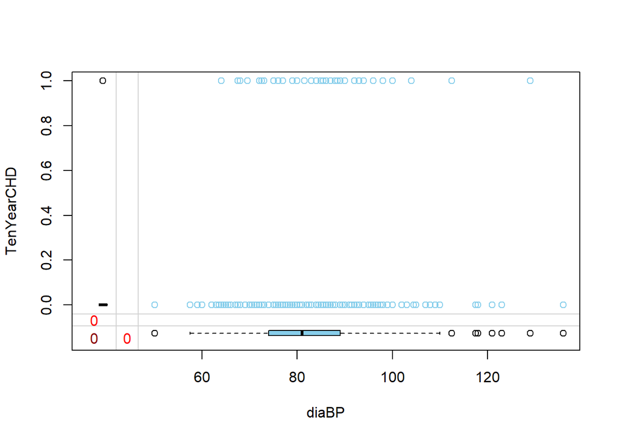

```r
# Margin plot. Red dots have at least one missing.
marginplot(df_miss[,c("diaBP","TenYearCHD")])
```

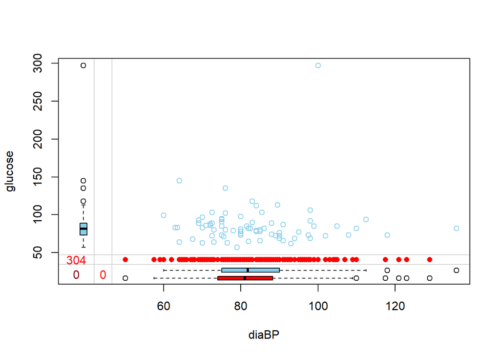

```r
marginplot(df_miss[,c("diaBP","glucose")])
```

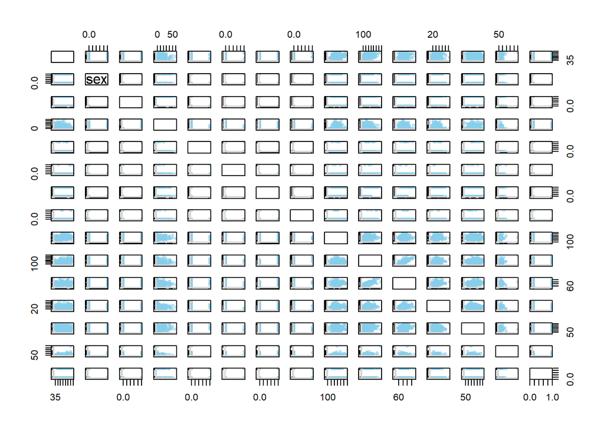

```r
marginmatrix(df_miss,alpha=0.8)
```

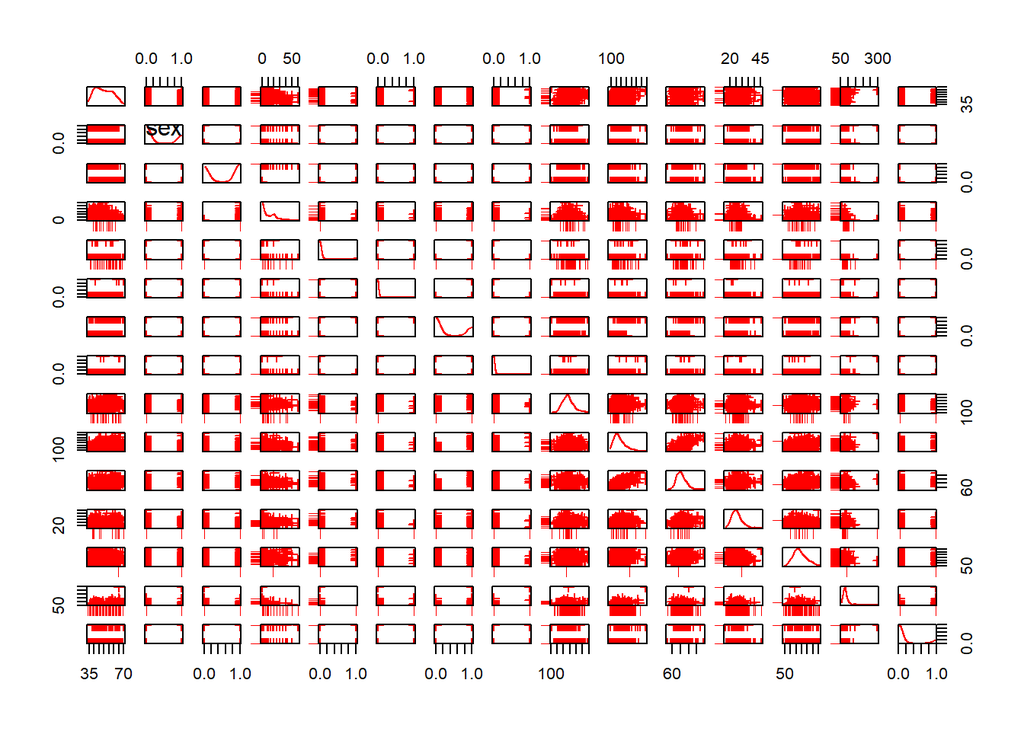

```r
scattmatrixMiss(df_miss, interactive = F)
```

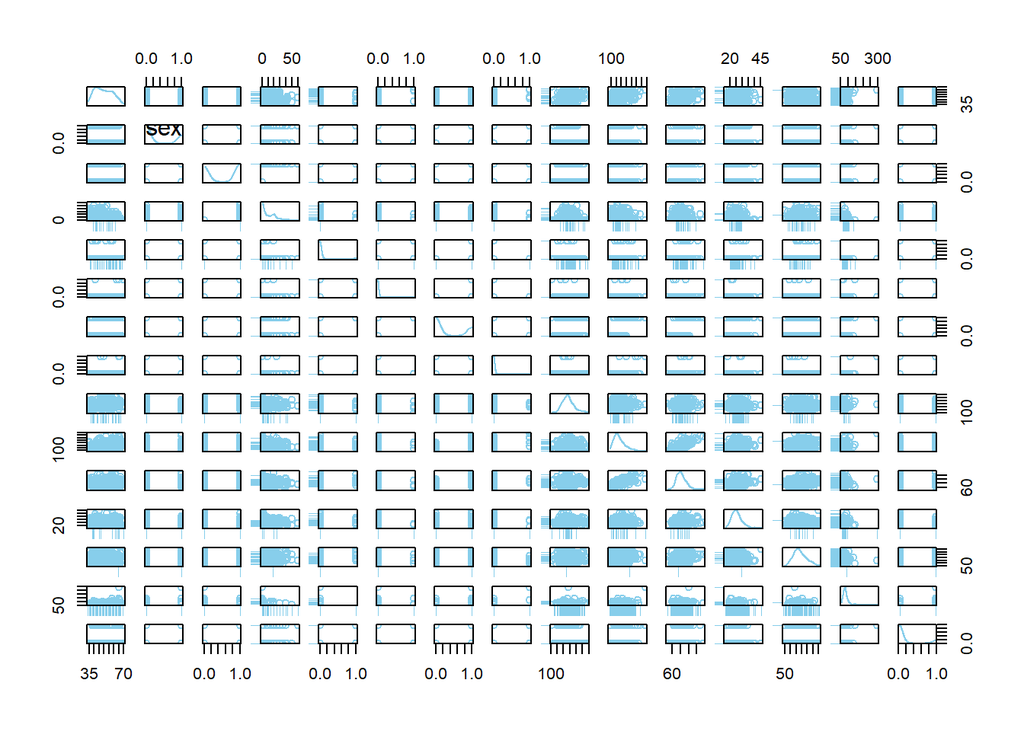

```r
scattmatrixMiss(df_miss, interactive = F, highlight="TenYearCHD")
```

#Impute the missing values

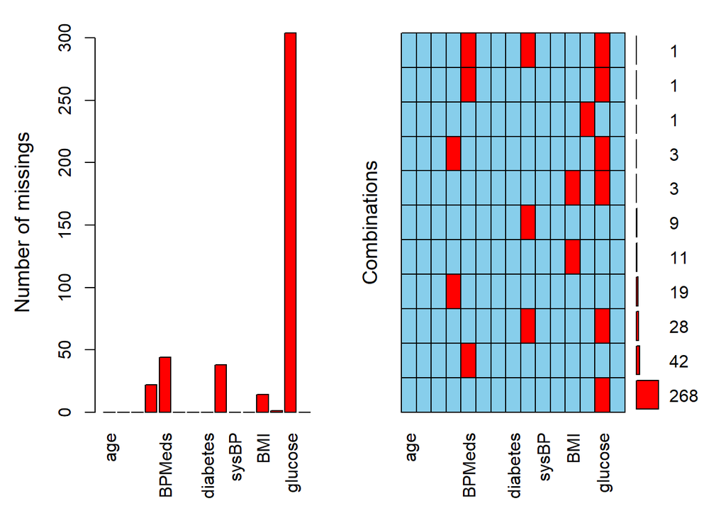

```r
# imputing missing values using knn for two variables
df_imputed<-kNN(df_miss, variable=c("diaBP","TenYearCHD"))
aggr(df_imputed, delimiter="_imp",prop=FALSE, numbers=TRUE)
```

```r
summary(df_imputed)
```

```
##       age             sex           is_smoking       cigsPerDay
##  Min.   :34.00   Min.   :0.0000   Min.   :0.0000   Min.   : 0.000
##  1st Qu.:42.25   1st Qu.:0.0000   1st Qu.:0.0000   1st Qu.: 0.000
##  Median :49.00   Median :0.0000   Median :1.0000   Median : 1.500
##  Mean   :49.70   Mean   :0.3109   Mean   :0.5363   Mean   : 8.995
##  3rd Qu.:57.00   3rd Qu.:1.0000   3rd Qu.:1.0000   3rd Qu.:20.000
##  Max.   :70.00   Max.   :1.0000   Max.   :1.0000   Max.   :60.000
##                                                    NA's   :22
##      BPMeds        prevalentStroke    prevalentHyp       diabetes
##  Min.   :0.00000   Min.   :0.00000   Min.   :0.0000   Min.   :0.00000
##  1st Qu.:0.00000   1st Qu.:0.00000   1st Qu.:0.0000   1st Qu.:0.00000
##  Median :0.00000   Median :0.00000   Median :0.0000   Median :0.00000
##  Mean   :0.02632   Mean   :0.01036   Mean   :0.3187   Mean   :0.01295
##  3rd Qu.:0.00000   3rd Qu.:0.00000   3rd Qu.:1.0000   3rd Qu.:0.00000
##  Max.   :1.00000   Max.   :1.00000   Max.   :1.0000   Max.   :1.00000
##  NA's   :44
##     totChol          sysBP           diaBP             BMI
##  Min.   :107.0   Min.   : 95.0   Min.   : 50.00   Min.   :16.61
##  1st Qu.:205.0   1st Qu.:117.5   1st Qu.: 74.00   1st Qu.:22.73
##  Median :232.5   Median :127.5   Median : 81.00   Median :25.09
##  Mean   :235.8   Mean   :132.7   Mean   : 82.57   Mean   :25.56
##  3rd Qu.:261.0   3rd Qu.:144.0   3rd Qu.: 89.00   3rd Qu.:27.64
##  Max.   :391.0   Max.   :235.0   Max.   :136.00   Max.   :45.79
##  NA's   :38                                       NA's   :14
##    heartRate         glucose         TenYearCHD     diaBP_imp
##  Min.   : 48.00   Min.   : 57.00   Min.   :0.0000   Mode :logical
##  1st Qu.: 69.00   1st Qu.: 73.00   1st Qu.:0.0000   FALSE:386
##  Median : 75.00   Median : 81.50   Median :0.0000
##  Mean   : 77.23   Mean   : 85.51   Mean   :0.1399
##  3rd Qu.: 85.00   3rd Qu.: 89.00   3rd Qu.:0.0000
##  Max.   :112.00   Max.   :297.00   Max.   :1.0000
##  NA's   :1        NA's   :304
##  TenYearCHD_imp
##  Mode :logical
##  FALSE:386
##
##
##
##
##
```

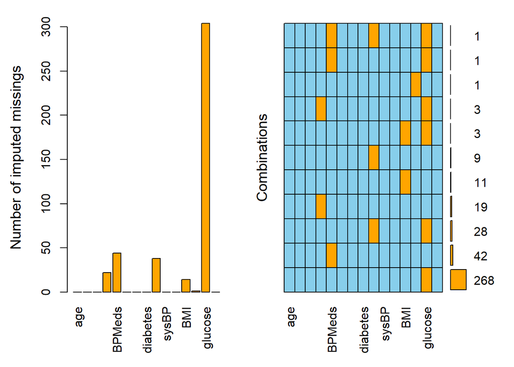

```r
# imputing missing values using knn for all variables
df_imputed<-kNN(df_miss)
aggr(df_imputed, delimiter="_imp",prop=FALSE, numbers=TRUE)
```

```r
summary(df_imputed)
```

```
##       age             sex           is_smoking       cigsPerDay
##  Min.   :34.00   Min.   :0.0000   Min.   :0.0000   Min.   : 0.000
##  1st Qu.:42.25   1st Qu.:0.0000   1st Qu.:0.0000   1st Qu.: 0.000
##  Median :49.00   Median :0.0000   Median :1.0000   Median : 3.000
##  Mean   :49.70   Mean   :0.3109   Mean   :0.5363   Mean   : 9.407
##  3rd Qu.:57.00   3rd Qu.:1.0000   3rd Qu.:1.0000   3rd Qu.:20.000
##  Max.   :70.00   Max.   :1.0000   Max.   :1.0000   Max.   :60.000
##      BPMeds        prevalentStroke    prevalentHyp       diabetes
##  Min.   :0.00000   Min.   :0.00000   Min.   :0.0000   Min.   :0.00000
##  1st Qu.:0.00000   1st Qu.:0.00000   1st Qu.:0.0000   1st Qu.:0.00000
##  Median :0.00000   Median :0.00000   Median :0.0000   Median :0.00000
##  Mean   :0.02332   Mean   :0.01036   Mean   :0.3187   Mean   :0.01295
##  3rd Qu.:0.00000   3rd Qu.:0.00000   3rd Qu.:1.0000   3rd Qu.:0.00000
##  Max.   :1.00000   Max.   :1.00000   Max.   :1.0000   Max.   :1.00000
##     totChol          sysBP           diaBP             BMI
##  Min.   :107.0   Min.   : 95.0   Min.   : 50.00   Min.   :16.61
##  1st Qu.:209.0   1st Qu.:117.5   1st Qu.: 74.00   1st Qu.:22.82
##  Median :234.0   Median :127.5   Median : 81.00   Median :25.14
##  Mean   :236.3   Mean   :132.7   Mean   : 82.57   Mean   :25.57
##  3rd Qu.:260.8   3rd Qu.:144.0   3rd Qu.: 89.00   3rd Qu.:27.53
##  Max.   :391.0   Max.   :235.0   Max.   :136.00   Max.   :45.79
##    heartRate         glucose         TenYearCHD      age_imp
##  Min.   : 48.00   Min.   : 57.00   Min.   :0.0000   Mode :logical
##  1st Qu.: 69.00   1st Qu.: 75.00   1st Qu.:0.0000   FALSE:386
##  Median : 75.00   Median : 82.00   Median :0.0000
##  Mean   : 77.23   Mean   : 81.98   Mean   :0.1399
##  3rd Qu.: 85.00   3rd Qu.: 85.00   3rd Qu.:0.0000
##  Max.   :112.00   Max.   :297.00   Max.   :1.0000
##   sex_imp        is_smoking_imp  cigsPerDay_imp  BPMeds_imp
##  Mode :logical   Mode :logical   Mode :logical   Mode :logical
##  FALSE:386       FALSE:386       FALSE:364       FALSE:342
##                                  TRUE :22        TRUE :44
##
##
##
##  prevalentStroke_imp prevalentHyp_imp diabetes_imp    totChol_imp
##  Mode :logical       Mode :logical    Mode :logical   Mode :logical
##  FALSE:386           FALSE:386        FALSE:386       FALSE:348
##                                                       TRUE :38
##
##
##
##  sysBP_imp       diaBP_imp        BMI_imp        heartRate_imp
##  Mode :logical   Mode :logical   Mode :logical   Mode :logical
##  FALSE:386       FALSE:386       FALSE:372       FALSE:385
##                                  TRUE :14        TRUE :1
##
##
##
##  glucose_imp     TenYearCHD_imp
##  Mode :logical   Mode :logical
##  FALSE:82        FALSE:386
##  TRUE :304
##
##
##
```

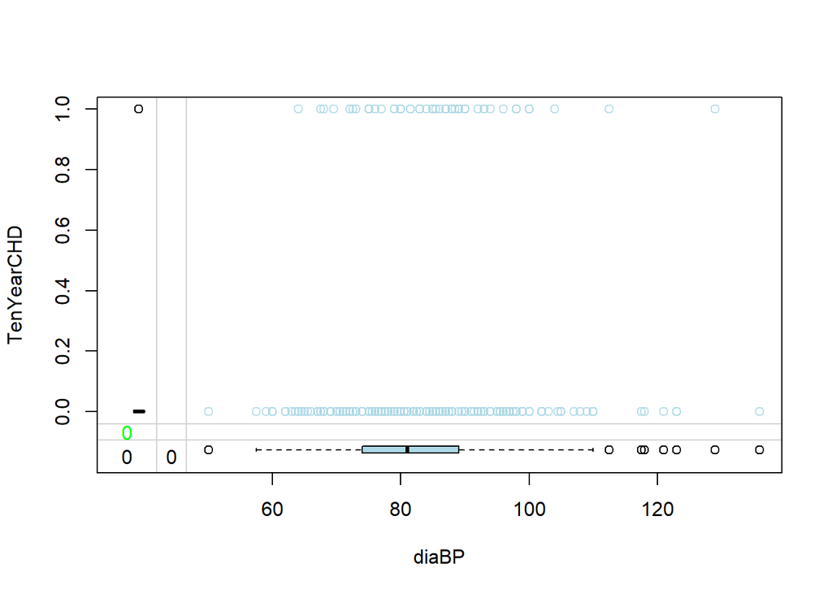

```r
#building margin plots with imputed values
marginplot(df_imputed[,c("diaBP","TenYearCHD",
                         "diaBP_imp","TenYearCHD_imp")],
           delimiter="imp",
           alpha = 0.8,
           col = c("lightblue", "green", "black"))
```

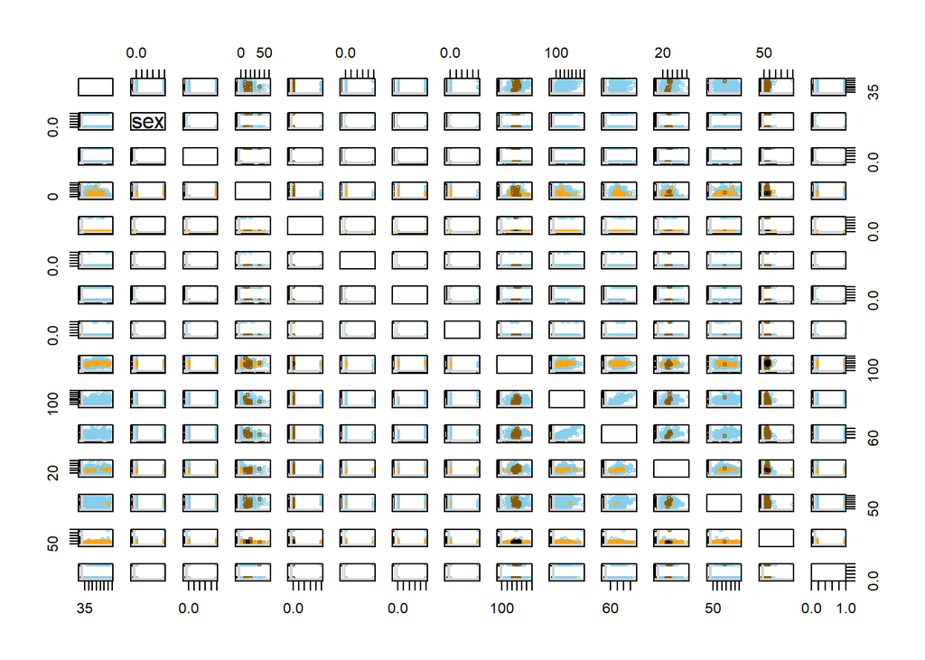

```r
marginmatrix(df_imputed, delimiter="_imp",alpha=0.8)
```

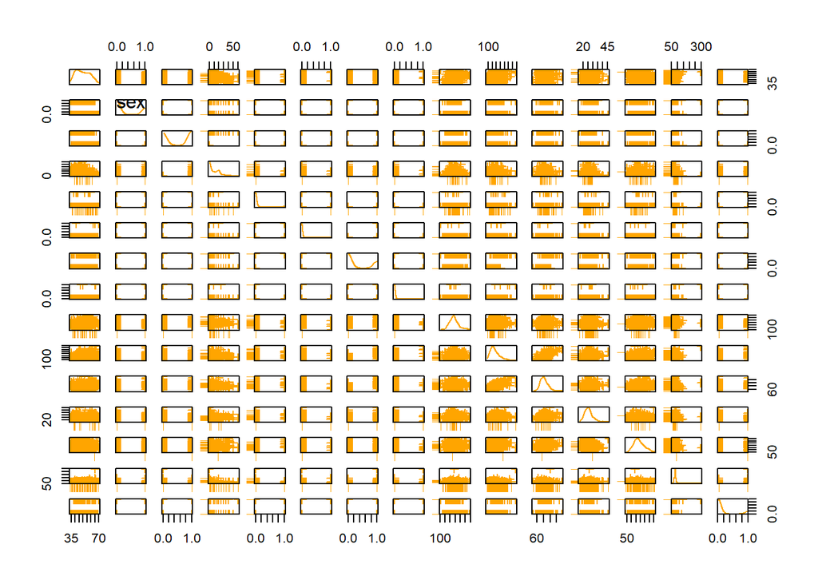

```r
scattmatrixMiss(df_imputed, delimiter="_imp", interactive = FALSE)
```

#Decision Tree Reading the data:

```r
setwd("C:/B452f")
dat <- read.csv("Cardiovascular_Study_Dataset.csv", header=TRUE)
dat = subset(dat, select = -c(education,id) )
str(dat)
```

```
## 'data.frame':    3390 obs. of  15 variables:
##  $ age            : int  64 36 46 50 64 61 61 36 41 55 ...
##  $ sex            : Factor w/ 2 levels "F","M": 1 2 1 2 1 1 2 2 1 1 ...
##  $ is_smoking     : Factor w/ 2 levels "NO","YES": 2 1 2 2 2 1 1 2 2 1 ...
##  $ cigsPerDay     : int  3 0 10 20 30 0 0 35 20 0 ...
##  $ BPMeds         : int  0 0 0 0 0 0 0 0 NA 0 ...
##  $ prevalentStroke: int  0 0 0 0 0 0 0 0 0 0 ...
##  $ prevalentHyp   : int  0 1 0 1 0 1 1 0 0 1 ...
##  $ diabetes       : int  0 0 0 0 0 0 0 0 0 0 ...
##  $ totChol        : int  221 212 250 233 241 272 238 295 220 326 ...
##  $ sysBP          : num  148 168 116 158 136 ...
##  $ diaBP          : num  85 98 71 88 85 121 136 68 78 81 ...
##  $ BMI            : num  NA 29.8 20.4 28.3 26.4 ...
##  $ heartRate      : int  90 72 88 68 70 85 75 60 86 85 ...
##  $ glucose        : int  80 75 94 94 77 65 79 63 79 NA ...
##  $ TenYearCHD     : int  1 0 0 1 0 1 0 0 0 0 ...
```

```r
head(dat)
```

```
##   age sex is_smoking cigsPerDay BPMeds prevalentStroke prevalentHyp diabetes
## 1  64   F        YES          3      0               0            0        0
## 2  36   M         NO          0      0               0            1        0
## 3  46   F        YES         10      0               0            0        0
## 4  50   M        YES         20      0               0            1        0
## 5  64   F        YES         30      0               0            0        0
## 6  61   F         NO          0      0               0            1        0
##   totChol sysBP diaBP   BMI heartRate glucose TenYearCHD
## 1     221 148.0    85    NA        90      80          1
## 2     212 168.0    98 29.77        72      75          0
## 3     250 116.0    71 20.35        88      94          0
## 4     233 158.0    88 28.26        68      94          1
## 5     241 136.5    85 26.42        70      77          0
## 6     272 182.0   121 32.80        85      65          1
```

```r
#makeing is_smoking and sex column to numeric variable
dat$is_smoking <- ifelse(dat$is_smoking=="YES", 1, 0)
dat$sex <- ifelse(dat$sex=="M", 1, 0)
#cancel missing data
anyNA(dat)
```

```
## [1] TRUE
```

```r
dat<- na.omit(dat)
dat1 <- filter(dat, TenYearCHD == 1 )
#change TenYearCHD to become factor

dat1 <-rbind(dat1,dat1,dat1,dat1,dat1)
dat<-rbind(dat1,dat)
dat$TenYearCHD = factor(dat$TenYearCHD, levels = c(0, 1))

anyNA(dat)
```

```
## [1] FALSE
```

```r
dat<- na.omit(dat)
set.seed(123)
split = sample.split(dat$TenYearCHD, SplitRatio = 0.7)

training_set = subset(dat, split == TRUE)

test_set = subset(dat, split == FALSE)


training_set[-15] = scale(training_set[-15])
test_set[-15] = scale(test_set[-15])

cart_task <- makeClassifTask(id = "dt", data = training_set,
                             target = "TenYearCHD")
cart_task
```

```
## Supervised task: dt
## Type: classif
## Target: TenYearCHD
## Observations: 3702
## Features:
##    numerics     factors     ordered functionals
##          14           0           0           0
## Missings: FALSE
## Has weights: FALSE
## Has blocking: FALSE
## Has coordinates: FALSE
## Classes: 2
##    0    1
## 1783 1919
## Positive class: 0
```

We use 70% data for tanning and 30% data for test.

```r
# check parameter sets of learner
getParamSet(makeLearner("classif.rpart"))
```

```
##                    Type len  Def   Constr Req Tunable Trafo
## minsplit        integer   -   20 1 to Inf   -    TRUE     -
## minbucket       integer   -    - 1 to Inf   -    TRUE     -
## cp              numeric   - 0.01   0 to 1   -    TRUE     -
## maxcompete      integer   -    4 0 to Inf   -    TRUE     -
## maxsurrogate    integer   -    5 0 to Inf   -    TRUE     -
## usesurrogate   discrete   -    2    0,1,2   -    TRUE     -
## surrogatestyle discrete   -    0      0,1   -    TRUE     -
## maxdepth        integer   -   30  1 to 30   -    TRUE     -
## xval            integer   -   10 0 to Inf   -   FALSE     -
## parms           untyped   -    -        -   -    TRUE     -
```

```r
getHyperPars(makeLearner("classif.rpart"))
```

```
## $xval
## [1] 0
```

```r
# create a rpart learners
cart_lrn <- makeLearner("classif.rpart", minsplit=3, minbucket=1, cp=0.001,
                        xval=10,
                        parms=list(split="gini"))
cart_lrn
```

```
## Learner classif.rpart from package rpart
## Type: classif
## Name: Decision Tree; Short name: rpart
## Class: classif.rpart
## Properties: twoclass,multiclass,missings,numerics,factors,ordered,prob,weights,featimp
## Predict-Type: response
## Hyperparameters: xval=10,minsplit=3,minbucket=1,cp=0.001,parms=split=gini
```

```r
# train the decision tree classifier
cart_mod <- train(cart_lrn, cart_task)
cart_mod$learner.model
```

```
## n= 3702
##
## node), split, n, loss, yval, (yprob)
##       * denotes terminal node
##
##      1) root 3702 1783 1 (0.48163155 0.51836845)
##        2) age< -0.360504 1428  481 0 (0.66316527 0.33683473)
##          4) cigsPerDay< 0.61388 818  201 0 (0.75427873 0.24572127)
##            8) diaBP< 1.745364 780  172 0 (0.77948718 0.22051282)
##             16) glucose< 1.001322 756  156 0 (0.79365079 0.20634921)
##               32) totChol< 3.917936 750  150 0 (0.80000000 0.20000000)
##                 64) glucose>=-0.7588776 721  135 0 (0.81276006 0.18723994)
##                  128) heartRate>=0.1339295 247   23 0 (0.90688259 0.09311741)
##                    256) age< -1.050272 123    0 0 (1.00000000 0.00000000) *
##                    257) age>=-1.050272 124   23 0 (0.81451613 0.18548387)
##                      514) heartRate< 1.255853 86    8 0 (0.90697674 0.09302326)
##                       1028) sysBP>=-1.522542 84    6 0 (0.92857143 0.07142857)
##                         2056) glucose>=-0.4154239 72    2 0 (0.97222222 0.02777778) *
##                         2057) glucose< -0.4154239 12    4 0 (0.66666667 0.33333333)
##                           4114) cigsPerDay< -0.03141957 8    0 0 (1.00000000 0.00000000) *
##                           4115) cigsPerDay>=-0.03141957 4    0 1 (0.00000000 1.00000000) *
##                       1029) sysBP< -1.522542 2    0 1 (0.00000000 1.00000000) *
##                      515) heartRate>=1.255853 38   15 0 (0.60526316 0.39473684)
##                       1030) totChol>=-0.2686526 13    0 0 (1.00000000 0.00000000) *
##                       1031) totChol< -0.2686526 25   10 1 (0.40000000 0.60000000)
##                         2062) heartRate>=1.546722 12    3 0 (0.75000000 0.25000000)
##                           4124) totChol< -0.3530171 9    0 0 (1.00000000 0.00000000) *
##                           4125) totChol>=-0.3530171 3    0 1 (0.00000000 1.00000000) *
##                         2063) heartRate< 1.546722 13    1 1 (0.07692308 0.92307692) *
##                  129) heartRate< 0.1339295 474  112 0 (0.76371308 0.23628692)
##                    258) sysBP< -0.7721996 209   28 0 (0.86602871 0.13397129)
##                      516) totChol< 1.397546 201   22 0 (0.89054726 0.10945274)
##                       1032) sysBP>=-1.362469 160    9 0 (0.94375000 0.05625000) *
##                       1033) sysBP< -1.362469 41   13 0 (0.68292683 0.31707317)
##                         2066) BMI< -0.4671075 23    0 0 (1.00000000 0.00000000) *
##                         2067) BMI>=-0.4671075 18    5 1 (0.27777778 0.72222222)
##                           4134) heartRate< -0.9464412 3    0 0 (1.00000000 0.00000000) *
##                           4135) heartRate>=-0.9464412 15    2 1 (0.13333333 0.86666667)
##                             8270) glucose>=-0.1292126 2    0 0 (1.00000000 0.00000000) *
##                             8271) glucose< -0.1292126 13    0 1 (0.00000000 1.00000000) *
```

[output cut: 407 more lines]

```
##                            16230) sysBP>=2.209159 2    0 0 (1.00000000 0.00000000) *
##                            16231) sysBP< 2.209159 58    9 1 (0.15517241 0.84482759)
##                              32462) glucose< -0.4726662 2    0 0 (1.00000000 0.00000000) *
##                              32463) glucose>=-0.4726662 56    7 1 (0.12500000 0.87500000) *
##                       2029) BMI>=0.2123227 77   10 1 (0.12987013 0.87012987)
##                         4058) totChol< -1.091206 3    0 0 (1.00000000 0.00000000) *
##                         4059) totChol>=-1.091206 74    7 1 (0.09459459 0.90540541)
##                           8118) heartRate< -1.195758 2    0 0 (1.00000000 0.00000000) *
##                           8119) heartRate>=-1.195758 72    5 1 (0.06944444 0.93055556) *
##                     1015) totChol>=0.4906279 69    5 1 (0.07246377 0.92753623) *
##                127) glucose>=0.01389308 175   15 1 (0.08571429 0.91428571)
##                  254) diaBP< 0.2377745 23    7 1 (0.30434783 0.69565217)
##                    508) glucose< 0.4432101 5    0 0 (1.00000000 0.00000000) *
##                    509) glucose>=0.4432101 18    2 1 (0.11111111 0.88888889) *
##                  255) diaBP>=0.2377745 152    8 1 (0.05263158 0.94736842) *
```

```r
cart_mod$features
```

```
##  [1] "age"             "sex"             "is_smoking"      "cigsPerDay"
##  [5] "BPMeds"          "prevalentStroke" "prevalentHyp"    "diabetes"
##  [9] "totChol"         "sysBP"           "diaBP"           "BMI"
## [13] "heartRate"       "glucose"
```

```r
cart_mod$time
```

```
## [1] 0.17
```

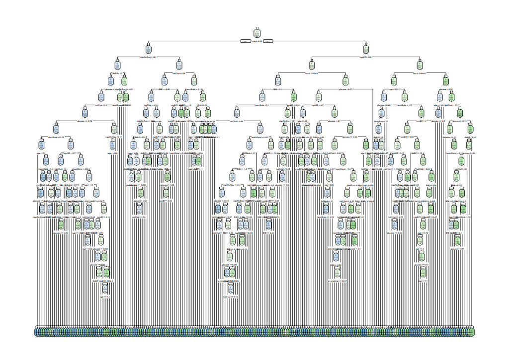

```r
# plot the tree
library(rpart.plot)
rpart.plot(cart_mod$learner.model, nn=TRUE, roundint=FALSE)
```

```r
train_pred <- predict(cart_mod, cart_task); train_pred
```

```
## Prediction: 3702 observations
## predict.type: response
## threshold:
## time: 0.01
##    id truth response
## 1   1     1        1
## 3   2     1        1
## 6   3     1        1
## 7   4     1        1
## 9   5     1        1
## 10  6     1        1
## ... (#rows: 3702, #cols: 3)
```

```r
test_pred <- predict(cart_mod, newdata=test_set); test_pred
```

```
## Prediction: 1587 observations
## predict.type: response
## threshold:
## time: 0.00
##    truth response
## 2      1        1
## 4      1        1
## 5      1        1
## 8      1        1
## 11     1        1
## 16     1        1
## ... (#rows: 1587, #cols: 2)
```

This is the CART decision tree classification. It uses 3702 observations of training set and 1587 observations of test set

```r
# confusion matrix
calculateConfusionMatrix(train_pred)
```

```
##         predicted
## true        0    1 -err.-
##   0      1648  135    135
##   1        35 1884     35
##   -err.-   35  135    170
```

```r
calculateConfusionMatrix(test_pred)
```

```
##         predicted
## true       0   1 -err.-
##   0      577 187    187
##   1      118 705    118
##   -err.- 118 187    305
```

```r
# Relative confusion matrix (normalized by row/column)
calculateConfusionMatrix(train_pred, relative = TRUE, sums = TRUE)
```

```
## Relative confusion matrix (normalized by row/column):
##         predicted
## true     0         1         -err.-    -n-
##   0      0.92/0.98 0.08/0.07 0.08      1683
##   1      0.02/0.02 0.98/0.93 0.02      2019
##   -err.-      0.02      0.07 0.05      <NA>
##   -n-    1783      1919      <NA>      3702
##
##
## Absolute confusion matrix:
##           0    1 -err.-  -n-
## 0      1648  135    135 1783
## 1        35 1884     35 1919
## -err.-   35  135    170   NA
## -n-    1683 2019     NA 3702
```

```r
calculateConfusionMatrix(test_pred, relative = TRUE, sums = TRUE)
```

```
## Relative confusion matrix (normalized by row/column):
##         predicted
## true     0         1         -err.-    -n-
##   0      0.76/0.83 0.24/0.21 0.24      695
##   1      0.14/0.17 0.86/0.79 0.14      892
##   -err.-      0.17      0.21 0.19      <NA>
##   -n-    764       823       <NA>      3702
##
##
## Absolute confusion matrix:
##          0   1 -err.-  -n-
## 0      577 187    187  764
## 1      118 705    118  823
## -err.- 118 187    305   NA
## -n-    695 892     NA 3702
```

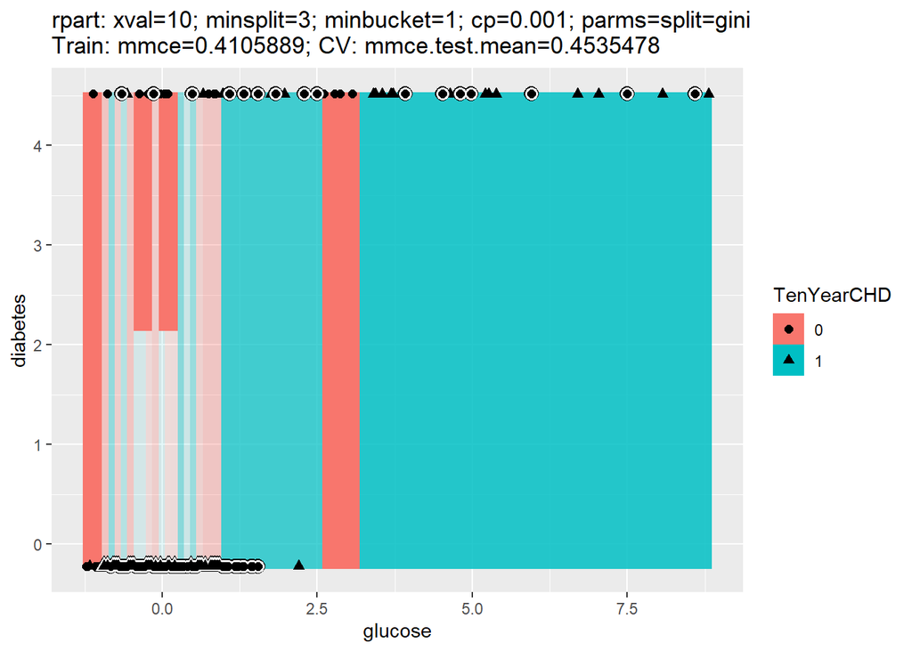

```r
# Visualizing the prediction
plotLearnerPrediction(cart_lrn, task = cart_task,
                      features = c("glucose", "diabetes"))
```

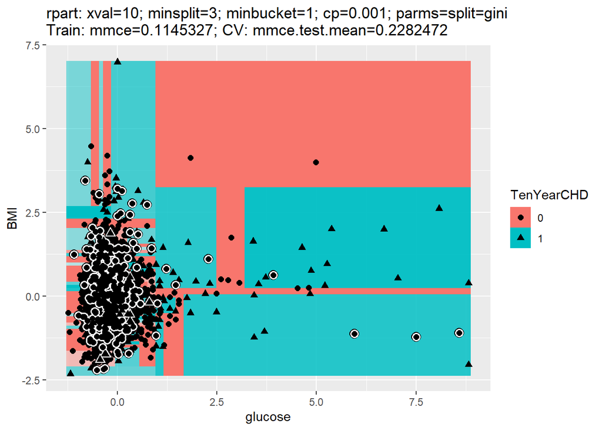

```r
plotLearnerPrediction(cart_lrn, task = cart_task,
                      features = c("glucose", "BMI"))
```

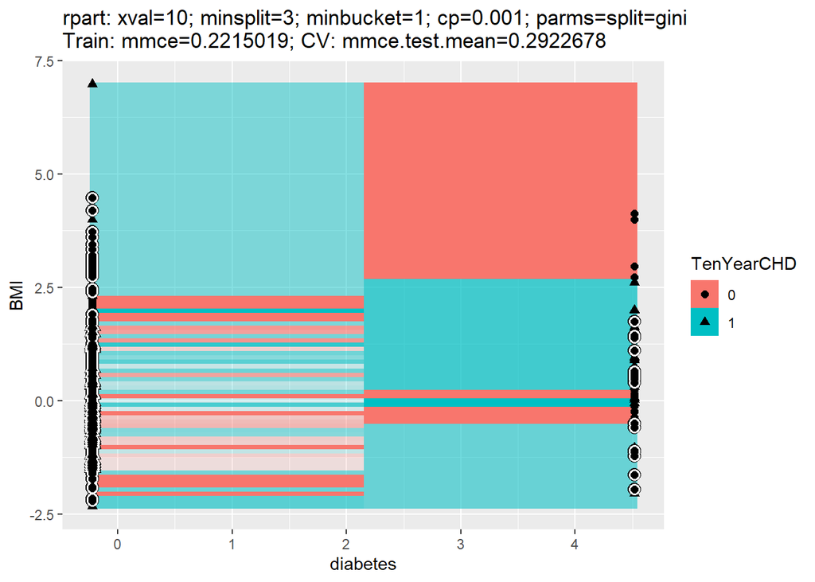

```r
plotLearnerPrediction(cart_lrn, task = cart_task,
                      features = c("diabetes", "BMI"))
```

For relative confusion matrix between glucose and diabetes. Before 2.5 numerical value of glucose, there are no absolute certainty of relationship between diabetes and glucose for confirming the patients has CHD in 10 years.After around 3 numerical value of glucose, patients who has diabetes and high numerical value of glucose tend to have the CHD in 10 years.

For relative confusion matrix between BMI and glucose. Patients who has high numerical value of BMI and low numerical value of glucose tend to have CHD in 10 years. High numerical value of glucose and high numerical value of BMI not tend to have CHD in 10 years.

For relative confusion matrix between BMI and diabetes. Patients who has high numerical value of BMI and no diabetes tend to have CHD in 10 years.Patients who has high numerical value of BMI and diabetes not tend to have CHD in 10 years.

```r
## Performance measure suitable for the cart classification task
listMeasures(cart_task)
```

```
##  [1] "tnr"              "tpr"              "featperc"         "f1"
##  [5] "mmce"             "mcc"              "brier.scaled"     "lsr"
##  [9] "bac"              "fn"               "fp"               "fnr"
## [13] "qsr"              "fpr"              "npv"              "brier"
## [17] "auc"              "timeboth"         "multiclass.aunp"  "timetrain"
## [21] "multiclass.aunu"  "ber"              "timepredict"      "multiclass.brier"
## [25] "ssr"              "ppv"              "acc"              "logloss"
## [29] "wkappa"           "tn"               "tp"               "multiclass.au1p"
## [33] "multiclass.au1u"  "fdr"              "kappa"            "gpr"
## [37] "gmean"
```

```r
### Get the default measure for rpart learner
getDefaultMeasure(cart_lrn)
```

```
## Name: Mean misclassification error
## Performance measure: mmce
## Properties: classif,classif.multi,req.pred,req.truth
## Minimize: TRUE
## Best: 0; Worst: 1
## Aggregated by: test.mean
## Arguments:
## Note: Defined as: mean(response != truth)
```

```r
# performance of prediction

performance(test_pred) # default mmce
```

```
##      mmce
## 0.1921865
```

```r
performance(test_pred, measures=acc)
```

```
##       acc
## 0.8078135
```

```r
rdesc <- makeResampleDesc(method = "CV", iters=10)
```

```r
# tune cp
num_ps <- makeParamSet(
  makeNumericParam("cp", lower = -5, upper = 5, trafo =
                     function(x) 10^x)
)
ctrl <- makeTuneControlRandom(maxit = 200L)
# use the optimized learns for benchmakring
res <- tuneParams(cart_lrn, task = cart_task,
                  resampling = rdesc,
                  par.set = num_ps,
                  control = ctrl,
                  measures = list(acc, mmce),
                  show.info = FALSE)
res
```

```
## Tune result:
## Op. pars: cp=0.000104
## acc.test.mean=0.9003264,mmce.test.mean=0.0996736
```

```r
res$x
```

```
## $cp
## [1] 0.0001036994
```

```r
res$y
```

```
##  acc.test.mean mmce.test.mean
##     0.90032636     0.09967364
```

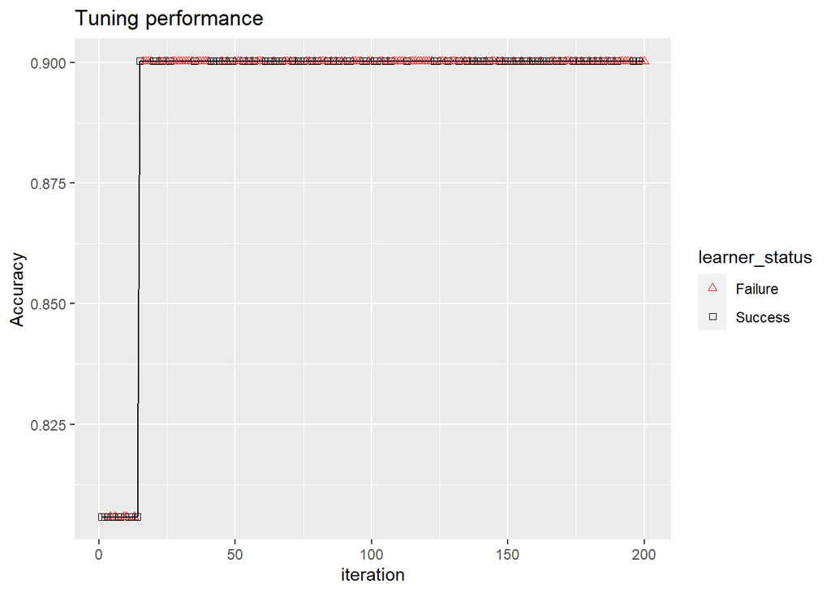

```r
#investigating hyperparameter tuning effects
data <- generateHyperParsEffectData(res, trafo=TRUE)
pl <- plotHyperParsEffect(data, x = "iteration", y = "acc.test.mean",
                          plot.type = "line")
# use ggplot2 function to change y-axis label and add title
pl + ggtitle("Tuning performance") + ylab("Accuracy")
```

```r
# update the hyperparameter
cart_lrn <- setHyperPars(cart_lrn, par.vals = res$x)
cart_lrn
```

```
## Learner classif.rpart from package rpart
## Type: classif
## Name: Decision Tree; Short name: rpart
## Class: classif.rpart
## Properties: twoclass,multiclass,missings,numerics,factors,ordered,prob,weights,featimp
## Predict-Type: response
## Hyperparameters: xval=10,minsplit=3,minbucket=1,cp=0.000104,parms=split=gini
```

```r
# retrain the model
cart_mod <- train(cart_lrn, cart_task)
cart_mod
```

```
## Model for learner.id=classif.rpart; learner.class=classif.rpart
## Trained on: task.id = dt; obs = 3702; features = 14
## Hyperparameters: xval=10,minsplit=3,minbucket=1,cp=0.000104,parms=split=gini
```

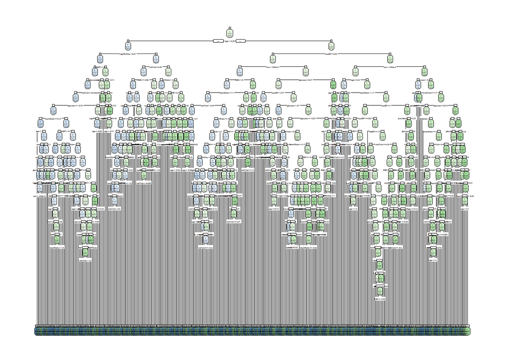

```r
rpart.plot(cart_mod$learner.model, nn=TRUE, roundint=FALSE)
```

```r
# prediction
test_pred<-predict(cart_mod, newdata = test_set)
# Relative confusion matrix (normalized by row/column)
calculateConfusionMatrix(test_pred, relative = TRUE, sums = TRUE)
```

```
## Relative confusion matrix (normalized by row/column):
##         predicted
## true     0         1         -err.-    -n-
##   0      0.82/0.85 0.18/0.16 0.18      730
##   1      0.13/0.15 0.87/0.84 0.13      857
##   -err.-      0.15      0.16 0.16      <NA>
##   -n-    764       823       <NA>      3702
##
##
## Absolute confusion matrix:
##          0   1 -err.-  -n-
## 0      624 140    140  764
## 1      106 717    106  823
## -err.- 106 140    246   NA
## -n-    730 857     NA 3702
```

```r
# performance of prediction
performance(test_pred) # default mmce
```

```
##      mmce
## 0.1550095
```

```r
performance(test_pred, measures=acc)
```

```
##       acc
## 0.8449905
```

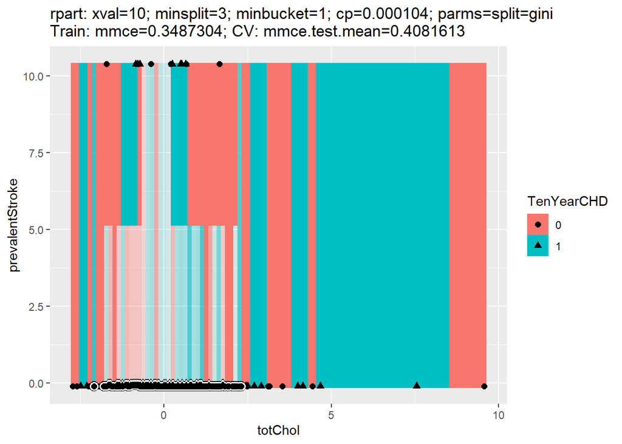

```r
# Visualizing the prediction
plotLearnerPrediction(cart_lrn, task = cart_task,
                      features = c("totChol", "prevalentStroke"))
```

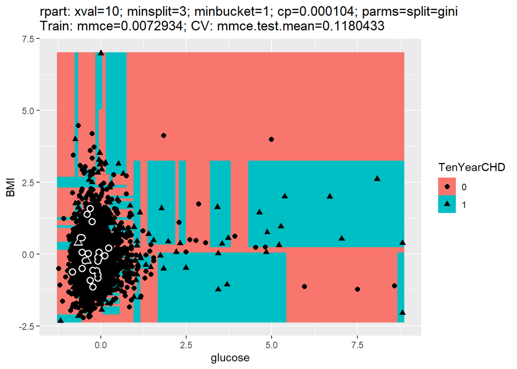

```r
plotLearnerPrediction(cart_lrn, task = cart_task,
                      features = c("glucose", "BMI"))
```

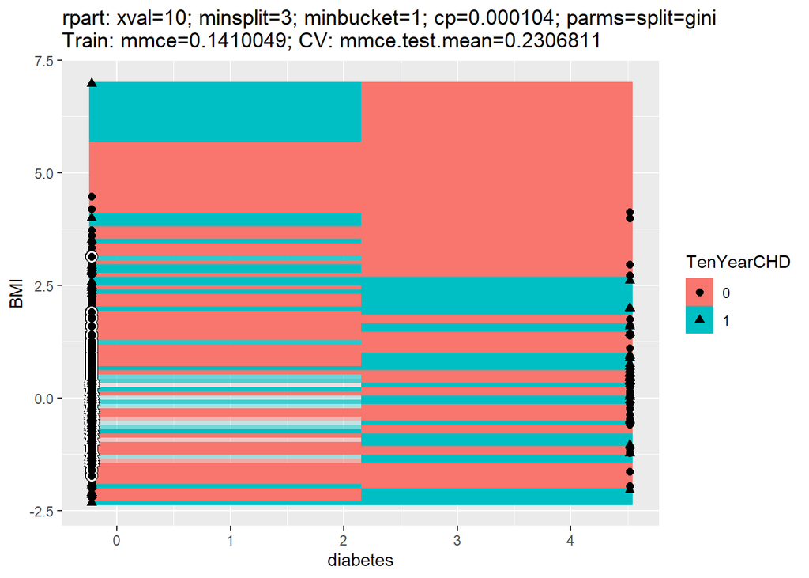

```r
plotLearnerPrediction(cart_lrn, task = cart_task,
                      features = c("diabetes", "BMI"))
```

The turning performance after around 15 iteration, the accuracy has over 0.9. After training the data, patients who has high numerical value of BMI and high glucose are not tend to have CHD in 10 years. After training the data, patients who has over 6.0 numerical value of BMI and no diabetes tend to have CHD in 10 years.Patients who has over 2.5 numerical value of BMI and diabetes not tend to have CHD in 10 years.

#Build C5.0 decision tree

```r
# create a C5.0 decision tree classification task
c50_task <- makeClassifTask(id = "dt", data = training_set,
                            target = "TenYearCHD")
c50_task
```

```
## Supervised task: dt
## Type: classif
## Target: TenYearCHD
## Observations: 3702
## Features:
##    numerics     factors     ordered functionals
##          14           0           0           0
## Missings: FALSE
## Has weights: FALSE
## Has blocking: FALSE
## Has coordinates: FALSE
## Classes: 2
##    0    1
## 1783 1919
## Positive class: 0
```

```r
# check parameter sets of learner
getParamSet(makeLearner("classif.C50"))
```

```
##                    Type len     Def      Constr Req Tunable Trafo
## trials          integer   -       1    1 to Inf   -    TRUE     -
## rules           logical   -   FALSE           -   -   FALSE     -
## subset          logical   -   FALSE           -   -    TRUE     -
## bands           integer   -       -  2 to 1e+03   Y   FALSE     -
## winnow          logical   -   FALSE           -   -    TRUE     -
## noGlobalPruning logical   -   FALSE           -   -    TRUE     -
## CF              numeric   -    0.25      0 to 1   -    TRUE     -
## minCases        integer   -       2    0 to Inf   -    TRUE     -
## fuzzyThreshold  logical   -   FALSE           -   -    TRUE     -
## sample          numeric   -       0  0 to 0.999   -    TRUE     -
## seed            integer   -       - -Inf to Inf   -   FALSE     -
## earlyStopping   logical   -    TRUE           -   -    TRUE     -
## label           untyped   - outcome           -   -   FALSE     -
```

```r
getHyperPars(makeLearner("classif.C50"))
```

```
## named list()
```

```r
# create a C5.0 learner
c50_lrn <- makeLearner("classif.C50", CF=0.1, minCases=2)
c50_lrn
```

```
## Learner classif.C50 from package C50
## Type: classif
## Name: C50; Short name: C50
## Class: classif.C50
## Properties: twoclass,multiclass,numerics,factors,prob,missings,weights
## Predict-Type: response
## Hyperparameters: CF=0.1,minCases=2
```

```r
# train the decision tree classifier
c50_mod <- train(c50_lrn, c50_task)
c50_mod$learner.model
```

```
##
## Call:
## C5.0.default(x = d$data, y = d$target, weights = .weights, control = ctrl)
##
## Classification Tree
## Number of samples: 3702
## Number of predictors: 14
##
## Tree size: 189
##
## Non-standard options: attempt to group attributes, confidence level: 0.1
```

```r
c50_mod$features
```

```
##  [1] "age"             "sex"             "is_smoking"      "cigsPerDay"
##  [5] "BPMeds"          "prevalentStroke" "prevalentHyp"    "diabetes"
##  [9] "totChol"         "sysBP"           "diaBP"           "BMI"
## [13] "heartRate"       "glucose"
```

```r
c50_mod$time
```

```
## [1] 0.32
```

```r
# get the tree model
tree<-c50_mod$learner.model

# make up the x and y arguments of the model and remove unnecessary ones
dummy<-function(x,y) match.call(expand.dots=TRUE)
arg<-dummy(x=training_set[,1:15],y=training_set$TenYearCHD)
arg
```

```
## dummy(x = training_set[, 1:15], y = training_set$TenYearCHD)
```

```r
arg$x
```

```
## training_set[, 1:15]
```

```r
arg$y
```

```
## training_set$TenYearCHD
```

```r
# update the tree's call function and plot the tree
tree<-c50_mod$learner.model
tree$call$x<-arg$x
tree$call$y<-arg$y
tree$call$weights<-NULL
tree$call$control<-NULL
tree$call # function call after updating
```

```
## C5.0.default(x = training_set[, 1:15], y = training_set$TenYearCHD)
```

[figure not shown]

```r
plot(tree)
```

```r
arg<-(function(x,y)match.call(expand.dots=TRUE))(training_set[,1:15],training_set$TenYearCHD)
```

This is c50 decision tree.

```r
train_pred <- predict(c50_mod, c50_task); train_pred
```

```
## Prediction: 3702 observations
## predict.type: response
## threshold:
## time: 0.30
##    id truth response
## 1   1     1        1
## 3   2     1        1
## 6   3     1        1
## 7   4     1        1
## 9   5     1        1
## 10  6     1        1
## ... (#rows: 3702, #cols: 3)
```

```r
test_pred <- predict(c50_mod, newdata=test_set); test_pred
```

```
## Prediction: 1587 observations
## predict.type: response
## threshold:
## time: 0.50
##    truth response
## 2      1        0
## 4      1        0
## 5      1        1
## 8      1        0
## 11     1        1
## 16     1        1
## ... (#rows: 1587, #cols: 2)
```

```r
# confusion matrix
calculateConfusionMatrix(train_pred)
```

```
##         predicted
## true        0    1 -err.-
##   0      1467  316    316
##   1        13 1906     13
##   -err.-   13  316    329
```

```r
calculateConfusionMatrix(test_pred)
```

```
##         predicted
## true       0   1 -err.-
##   0      312 452    452
##   1       83 740     83
##   -err.-  83 452    535
```

```r
# Relative confusion matrix (normalized by row/column)
calculateConfusionMatrix(train_pred, relative = TRUE, sums = TRUE)
```

```
## Relative confusion matrix (normalized by row/column):
##         predicted
## true     0           1           -err.-      -n-
##   0      0.823/0.991 0.177/0.142 0.177       1480
##   1      0.007/0.009 0.993/0.858 0.007       2222
##   -err.-       0.009       0.142 0.09        <NA>
##   -n-    1783        1919        <NA>        3702
##
##
## Absolute confusion matrix:
##           0    1 -err.-  -n-
## 0      1467  316    316 1783
## 1        13 1906     13 1919
## -err.-   13  316    329   NA
## -n-    1480 2222     NA 3702
```

```r
calculateConfusionMatrix(test_pred, relative = TRUE, sums = TRUE)
```

```
## Relative confusion matrix (normalized by row/column):
##         predicted
## true     0         1         -err.-    -n-
##   0      0.41/0.79 0.59/0.38 0.59      395
##   1      0.10/0.21 0.90/0.62 0.10      1192
##   -err.-      0.21      0.38 0.34      <NA>
##   -n-    764       823       <NA>      3702
##
##
## Absolute confusion matrix:
##          0    1 -err.-  -n-
## 0      312  452    452  764
## 1       83  740     83  823
## -err.-  83  452    535   NA
## -n-    395 1192     NA 3702
```

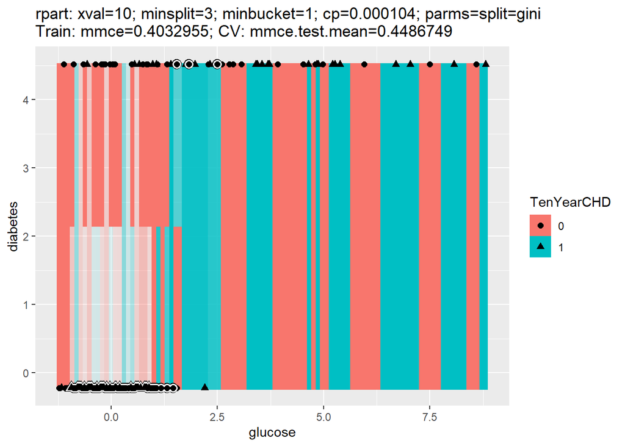

```r
# Visualizing the prediction
plotLearnerPrediction(cart_lrn, task = c50_task,
                      features = c("glucose", "diabetes"))
```